# Rapport d’activité

Alice Chevaux

# Présentation du projet

Dans le cadre d’un cours visant à nous initier au logiciel R. Nous avons eu carte blanche pour utiliser le temps mis à notre disposition afin de développer nos compétences en R.

Ce projet ne necessitait pas de fil conducteur mais seulement un rapport d’activité qui témoigne de notre progression sur différents aspects de R : ici je me suis concentrée sur une application R Shiny, et j’ai essayé à travers le développement de cette application de me familiariser avec d’autres outils tels que ggplot2 , RC++ et la programmation objet sur R.

J’ai décidé de centrer cette application autour de la thématique du test de personnalité. Je me suis vite rendue compte que le format test/quizz qui doit à la fois récolter des données et aussi rendre un résultat/score n’est pas si évident à traiter, et j’ai utilisé une base de donnée de kaggle contenant presque 20000 participation à un test de personnalité de 40 questions pour me familiariser avec de grands tableaux de données.

Le rendu de mon travail à ensuite été déployé à cette adresse:

[mon application](https://alnack.shinyapps.io/newapp/)

Ce rapport ne commentera pas tous les éléments de mon travail mais plutôt :

- les difficultés que j’ai eu à développer certaines fonctionnalités
- les choix que j’ai fait
- les éléments supplémentaires que j’avais créé mais qui n’avait finalement pas leur place dans mon application
- ceux qui ont été remplacés par quelque chose de plus perfomant

# Choix du format

### Base de données

Voici la base de données à partir de laquelle j’ai travaillé:

[base de données](https://www.kaggle.com/datasets/lucasgreenwell/ocean-five-factor-personality-test-responses?select=data.csv)

Pour la partie sondage de mon code j’ai supprimé les 7 premières questions qui sont des questions personnelles, je les utiliserai dans la partie Analyse de données en y faisant référence sous le nom de “questions facultatives”.

J’ai décidé dès le départ que j’allais m’attaquer à un format de type test/quizz car cela m’amusait de ne pas seulement collecter les données, mais aussi de rendre un “score” comme sur les magazines.

Cependant pour rendre le format le plus reproducible possible il fallait que je me restreigne sur la façon dont le “score” était calculé. Ici je me suis basé sur un test de personnalité dont chaque question fait écho à un certain paramètre (Ouverture d’esprit / Consciensiosité / Extraversion / Amabilité / Nevrosité ).

J’ai donc décidé de calculer le score en mettant pour chaque question un coefficient + ou -1 selon si elle allait dans le sens ou non du paramètre étudié. Puis en fonction de la réponse choisi je rajouter un certain nombre de point à ce paramètre. En divisant cela par un score maximum atteint pour chaque paramètre, je pouvais ensuite calculer un pourcentage atteint pour chaque paramètre.

Ce pourcentage est ce qui est rendu par mon application quand on remplit toutes les questions. Les données elles sont stockées comme sur kaggle, c’est à dire avec une réponse d’intensité entre 1 à 5 correspondant à : “Pas d’accord” = 1, “Pas trop d’accord” = 2, “Ni l’un ni l’autre” = 3, “Plutôt d’accord” = 4, “D’accord” = 5.

### Shiny dashboard & shiny surveys

En cherchant à commencer une application Shiny, j’ai débuté avec le ShinyDashboard qui fournit une base pour créer un site avec plusieurs onglets.

J’ai ensuite cherché à savoir si il y avait des fonctionnalités pour intégrer un sondage dans ce dashboard.

J’ai tout d’abord essayé d’utiliser le package ShinySurvey qui permet de faire des sondages. Néanmoins c’était laborieux et compliqué à mettre en place car les données à donner pour les questions ont un format très peu instinctif. Par exemple pour les questions à choix multiple il fallait les rentrer plusieurs fois pour chaque choix.

De plus, mon but étant de faire un test est non un simple sondage (la différence étant que le test rend un score/résultat là où le sondage ne fait que récolter des données), j’ai cherché à rendre un résultat directement dans le shinysurvey à la fin du sondage. Celui-ci prend la forme d’une fenètre qui s’ouvre en pop-up avec les questions du sondage, et peut afficher une page statique quand on valide ces résultats, mais rien qui dépendent directement des réponses.

Mais le plus gros soucis était que je n’arrivais pas a intégrer ça au shinydashboard non plus : le shinysurvey crée sa propre fenêtre pour le sondage et ce format n’est pas compatible avec la séparation UI/server des shiny dashboards.

J’ai alors songé à abandonner le ShinySurvey et à juste mettre une fenêtre pop-up dans mon dashboard avec le questionnaire en googleform, afin de récuperer les réponses sur mon compte google avant de les exploiter sur une autre page du dashboard, mais la mise en forme ne me plaisait pas et le procédé ne se faisait pas en direct à cause du délai pour récupérer les données.

C’est alors que j’ai trouvé un site qui avait paramétré un sondage à partir des fonctionnalités de base de ShinyDashboard et qui donnait son code en libre service sur son github:

[son sondage](https://conalmonaghan.shinyapps.io/two-dimensional_machiavellianism/)

[son github](https://github.com/ConalMonaghan/Shiny-Survey-and-Feedback-Site)

Au fur et à mesure mon code s’est grandement éloigné du sien mais il m’a permis de comprendre comment je pouvais exploiter les fonctionnalités de base avec les SelectInput afin de faire choisir à l’utilisateur quelque chose puis de récupérer son choix dans le serveur avec les input$ associés.

### Recuperation des resultats

Tout d’abord j’ai créé trois questions comme dans le site exemple, et je les ai utilisées comme base de travail. En cherchant dans les fonctions disponibles sur Shiny, j’ai découvert les trois mises en page possible pour les questions et j’ai finalement choisi la deuxième (Figure 1).

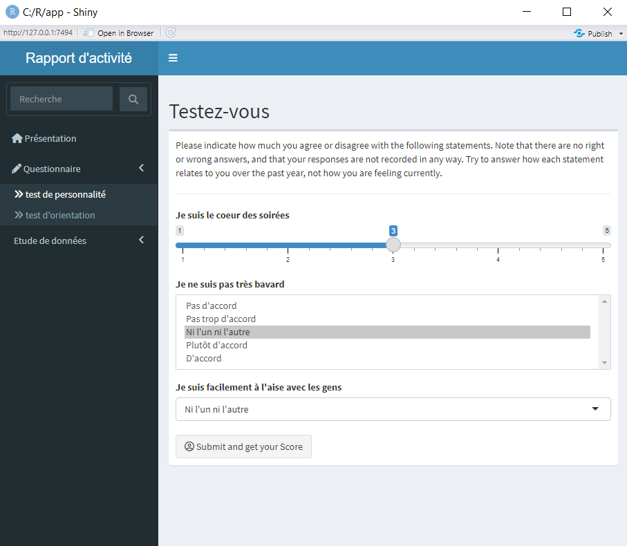

Figure 1: Trois formats de questions possibles

A partir de ces trois questions très simples, je me suis attaqué à la suite. Néanmoins même si c’était aisé de récupérer les données de l’utilisateur en cours, encore fallait-il les stockées.

La méthode préconisait par le site utilise le package googlesheet afin de collecter les données sur un googlesheet associé à son propre compte google afin de ne pas rendre les données publiques. Cependant ce package n’est plus disponible tel quel car il a été mis à jour avec googlesheets4.

Malheureusement j’ai pu me rendre compte que de nombreuses fonctionnalités avait disparues. Après avoir passé beaucoup de temps à traduire les anciennes fonctions par de nouvelles, j’ai finalement réussi à faire fonctionner l’application sur ma console, et quelque secondes après avoir répondu au sondage,une nouvelle ligne apparaissait sur un de mes documents google (Figure 2).

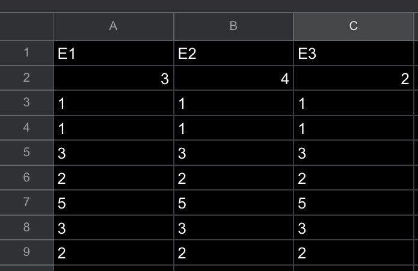

Figure 2: googlesheet correspondant

On a bien pour chaque question la réponse correspondante (sachant que 1: Pas d’accord et 5: D’accord ).

Néanmoins quand je déployais l’application sur Shinyapp, j’avais un message d’erreur.

Après quelques recherches j’ai compris que c’était la sécurité de mon compte google qui bloquait la connexion: quand je faisais tourner l’application sur ma console je pouvais valider manuellement ma connexion (malgré mon token je devais appuyer sur “entrée” à un moment) et ça ne fonctionnait donc plus quand je déployais l’application.

Je me suis donc rabattue sur une méthode plus simple mais qui nécessite alors de mettre les données dans un endroit où tout le monde peut les télécharger:

uploader avec mon application une dataframe qui contient les résultats, y rajouter à chaque fois la ligne des résultats et réenregistrer la dataframe. Et comme la dataframe est dans un dossier “www”, je peux y accéder en ajoutant /data à la fin du lien de mon application.

```r
observeEvent(input$n, {                                      #le observeevent s'active quand l'input est validé, ici il se valide lorsqu'on envoie le questionnaire à la fin des questions

    data<-rbind(data,as.vector(Results()))
    save(data,file='www/data.rda')
  })
```

Ce format put être problématique en fonction de la nature des informations collectées mais il fonctionne.

Il faut aussi noté qu’il est déconseillé d’utiliser une dataframe vide pour cette opération, il faut qu’elle ait 2-3 lignes de remplies pour être assurés que cela fonctionnera bien.

Dans mon cas je vais utiliser comme dataframe de départ celle obtenue sur kaggle qui compte donc déjà 20000 résultats.

Comme j’ai du remplir plusieurs fois le sondage pour verifier le fonctionnement de tout, j’ai aussi créé un code pour réinitialiser cette dataframe à partir de fichier datainitialle.csv afin de ne pas biaiser les resultats avec mes tests pour verifier si l app marche.

```r
data<-read.csv('datainitialle.csv',head=T,sep="")
save(data,file='www/data.rda')
```

# Mise en place et reproducibilité

### Format des données d’entrée

J’ai voulu rendre le code reproducible au maximum. Je ne l’ai fait que pour l’onglet ‘Test’ car l’onglet ‘Analyse de données’ n’a pas d’interêt à être reproducible, sachant que j’affiche déjà les histogrammes des résultats dans la partie reproducible.

A l’heure actuelle, il suffit d’avoir une dataframe ‘questions.csv’ comportant les questions et leur impact sur les paramètres étudiés, et une dataframe ‘www/data.rda’ comportant les réponses aux questions déjà collectées pour faire tourner cet onglet.

Il faut que les réponses attendues soit une mesure d’intensité de 1 à 5.

```r
setwd('C:/R/app/newapp')
load('www/data.rda')
head(data[1:4])
```

```
##   E1 E2 E3 E4
## 1  4  2  5  2
## 2  2  2  3  3
## 3  5  1  1  4
## 4  2  5  2  4
## 5  3  1  3  3
## 6  1  5  2  4
```

Pour la dataframe des questions il faut un identifiant pour chaque questions (qui ne peut être un entier),son intitulé, et et une constante qui quantifie l’impact de la question sur chaque paramètre (qui n’est pas obligé d’être 1 ou -1 comme dans l’exemple suivant, de même une question peut avoir un impact sur plusieurs paramètres).

Il faut bien que la dataframe est un header afin que l’on puisse extraire le nom des paramètres.

```r
setwd('C:/R/app/newapp')
questions<-read.csv('questions.csv',head=T)
head(questions)
```

```
##   id                                               q Ouverture.d.esprit
## 1 E1                   Je suis le coeur des soirÃ©es                  0
## 2 E2                     Je ne suis pas trÃ¨s bavard                  0
## 3 E3    Je suis facilement Ã  lâ\200\231aise avec les gens                  0
## 4 E4                    Je me met souvent en retrait                  0
## 5 E5                   Je commence les conversations                  0
## 6 E6 Je nâ\200\231aime pas exprimer dâ\200\231opinions tranchÃ©s                  0
##   ConscienciositÃ. Extraversion AmabilitÃ. Nevrotisme
## 1                0            1          0          0
## 2                0           -1          0          0
## 3                0            1          0          0
## 4                0           -1          0          0
## 5                0            1          0          0
## 6                0           -1          0          0
```

### Programmation Objet

J’ai aussi perdu du temps à développer une programmation objet sur les questions.

Meme si c’etait pratique au debut de pouvoir appeler les attributs, j’ai eu du mal à utiliser cela quand je voulais rendre mon code reproducible car ce n’etait pas compatible avec la forme dont je voulais donner au test au debut (une dataframe, et il fallait donner a chaque ligne la bonne classe objet).

J ai donc simplement utiliser la dataframe en nommant bien les colonnes pour que ca fasse comme les attributs.

```r
qu <- function(id,texte,resultatsrate) {
  being <- list(id=id,q=texte,rate=resultatsrate)
  class(being) <- "question"
  being
}
questionnaire <- function(dataframe,resultats) {
  being <- list(df=dataframe,res=resultats)
  class(being) <- "questionnaire"
  being
}
```

En fait ici je définissais deux classes distinctes, avec l’idée que chaque ligne du questionnaire était de classe question.

Or en utilisant simplement une dataframe contenant les questions, je pouvais juste nommer les colonnes et attacher la dataframe. Dès lors chaque ligne avait les mêmes attributs qu’en utilisant la programmation objet.

De plus comme je n’avais pas besoin des questions de manière isolée, mais simplement besoin de parcourir toutes les questions afin d’y appliquer à chaque fois la même fonction, ce n’était pas gênant de devoir utiliser df[i] pour la i ème question, même si c’était un peu plus long que si j’avais pu appeller la question par son id directement.

### Reproducibilité du questionnaire

Le code que j’ai écrit pour l’application charge tout d’abord un certain nombre de fonctions en éxécutant source(‘fonctions.R’).

Ce dossier contient notamment le chargement des dataframes questions et data, mais aussi des fonctions nécessaires pour la reproducibilité.

Par exemple pour faire apparaitre toutes les questions du test, j’ai du créé la fonctions g suivante:

```r
g=function(df){
  y=NULL
  for (i in c(1:nrow(df))){
    y<-list(y,selectInput(inputId = df[i,1] ,     #il faut utiliser list au lieu de append sinon des bouts de java script apparaissent
                            label = df[i,2],
                            choices = c("Pas d'accord" = 1, "Pas trop d'accord" = 2, "Ni l'un ni l'autre" = 3,
                                        "Plutôt d'accord" = 4, "D'accord" = 5),
                            selectize=F,
                            size=5,
                            selected = 3))
              }
  y
}
```

elle m’écrit le script nécessaire pour afficher toutes les questions de la dataframe correspondantes.

Il suffit alors d’ajouter g(questions) à l’endroit adéquat dans l’UI et en appelant l’application on a bien tout le questionnaire correspondant qui s’affiche.

### Reproducibilité des résultats

Cependant je n’ai pas réussi à faire de même pour ressortir les résultats.

Je voulais aussi utilisé une boucle for afin de faire apparaitre autant de graphiques que de paramêtres étudiés: ainsi j’aurais pu afficher l’histogramme des scores, avec une barre verticale correspondant au score de l’utilisateur.

J’ai essayé de generer les différents output$’nom’ dans une boucle for mais visiblement on ne peut pas définir de output dans un autre dossier que le serveur même si on l’exécute.

Et on ne peut pas non plus exécuter une boucle for directement dans le server (car rien ne l’appelle).

Voici les deux essais correspondants que j’avais fait :

```r
#ce que j'ai essayé demettre dans le server:

for (i in c(1:length(res))) {
  a<-renderText({
    paste("Votre score de",res[i],"est de",Score()[i])
  })
  assign(paste0('output$texte',i),a
  )
  b <- renderPlot({
    ggplot(dataquest,aes(x=dataquest[i]))+
      geom_vline(xintercept=Score()[i],size=1)+
      geom_vline(xintercept = 1,alpha=0)+
      geom_vline(xintercept = -1,alpha=0)+
      theme(
        # Masquer les bords des panneaux et supprimer les lignes de grilles
        panel.border = element_blank(),
        panel.grid.minor = element_blank(),
        panel.background = element_rect(fill = 'pink')
      )
    }
  )
  assign(paste0('output$plot',i),b
  )}

# mais même en appelant directement textOutput('plot1') ça ne marchait pas alorsque la boucle marchait bien et définissait les bonnes variables

f=function(sco) {
  s=NULL
  for (i in c(1:length(res))) {
    a<-renderText({
      paste("Votre score de",res[i],"est de",Score()[i])
    })
    assign(do.call('$',list(output,cat('texte',res[i]))),a)
    b <- renderPlot({
      ggplot(dataquest,aes(x=Extraversion))+
        geom_vline(xintercept=Score()[3],size=1)+
        geom_vline(xintercept = 1,alpha=0)+
        geom_vline(xintercept = -1,alpha=0)+
        theme(
          # Masquer les bords des panneaux et supprimer les lignes de grilles
          panel.border = element_blank(),
          panel.grid.minor = element_blank(),
          panel.background = element_rect(fill = 'pink')
        )
    }
    )
    assign(do.call('$',list(output,cat('plot',res[i]))),b)
  }
}
#et dans l ui:
textOutput("texte3"),plotOutput("plot3")
f(dataquest)

h=function(df){
  s=NULL
  for (i in c(1:length(res))) {
    s<-list(s,textOutput(cat('texte',res[i]),plotOutput(cat('plot',res[i]))))
  }
  s
}

#et ca comme fonction pour appeler dans l ui de façon reproducible
```

J’ai donc opté pour afficher un seul plot car je n’arrivais pas à en créer plein. Cela limitait cependant les possibilités, j’ai décidé de le faire à l’aide d’un barplot horizontal.

L’idée est que ça ne ressemble pas à un barplot mais à des barres plus ou moins remplies selon le score de l’utilisateur.

J’ai ensuite fait affiché le graphique des histogrammes des scores déjà collectés grace à ggplot2.

Malheureusement cette technique ne me permet pas de comparer directement les résultats de l’utilisateur avec ceux du reste du monde, je ne peux que juxtaposer les deux graphes.

Voici par exemple ce qui ressort :

[figure not shown]

Figure 3: score de l’utilisateur

[figure not shown]

Figure 4: histogramme des scores mis à jour

### RC++ : calcul des scores

Afin d’afficher le graphique de l’histogramme des scores, il faut calculer la fonction h qui calcule les scores à chaque ligne de www/data.rda Cela prend même en compte l’utilisateur actuel ce qui est pertinent.

J’avais tout d’abord défini la fonction h de façons basique dans R:

```r
h=function(x){
  z=replicate(length(res),0)
  for (j in c(1:length(res))){
    for (i in c(1:length(x))){
      z[j]=z[j]+(x[i]-3)*(as.vector(df1[[i,j+2]]))/2
    }
  }
  z
}
```

Et de la même façon en RC++

```r
library(Rcpp)
cppFunction('
 Rcpp::NumericVector cpp_h(Rcpp::NumericVector l,DataFrame df) {
   const int n = l.size();
   Rcpp::NumericVector result (5);
   const int m = result.size();
   for (int j=0;j<m;j++) {
     NumericVector v=df[j+2];
     for(int i=0; i<n; i++){
        result[j] = result[j]+(l[i]-3)*v[i]/2;
     };
   }
   return result;
 }
')
```

Après avoir programmer des fonctions htot et cpp_htot qui applique les fonctions précédentes à l’ensemble de la matrice des résultats data1, j’ai pu comparer la durée d’éxécution.

En temps normal la fonction htot mettait plusieurs minutes à s’éxécuter là où cpp_htot donnait un résultat immédiat. Pour mieux évaluer la différence on utilise la fonction microbenchmarks.

Cependant cette fonction faisant beaucoup d’essais, elle aurait mis des heures à ressortir une valeur de moyenne de temps pour la fonction htot appliquée à data1. J’ai donc apliquée microbenchmarks aux cent premières lignes de data1 en voici les résultats que j’ai eu

La deuxième fonction vérifie que les deux fonctions rendent le même résultat.

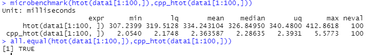

Figure 5: résultats microbenchmark

RC++ nous permet d’aller plus de 100 fois plus vite en moyenne.

# Pour aller plus loin

### Analyse des données

Ce n’étant pas le sujet du cours, je me suis contentée de simples ACPs et histogrammes bien choisis.

Ca aurait ete facile de mettre dans le code reproducible , d’ailleurs en realité ca reprend bien les résultats precedents et aurait pu ainsi placé l’utilisateur qui vient de répondre au test sur le graphe de l’ACP mais ca rendait la page un peu lourde et sans interprétation c’est délicat de proposer des graphes tels que l’ACP.

De plus, dans notre cas l’ACP est surtout pertinente grace aux questions supplémentaires qui ne sont disponibles que sur les données obtenues sur Kaggle.

### Questions facultatives

Néanmoins j’aurais voulu mettre des questions facultatives sur l age, gaucher/droitier, et le genre dans le test lui-même. Cependant cela necessite de manipuler constamment deux dataframe pour les résultats: la dataframe des résultats comme ici, et une remplie avec les résultats gens qui ont répondu aux questions facultatives, avec notamment ces questions facultatives.

Toutes les modifications sont de l’ordre de ce qu’on a fait jusqu’à maintenant mais cela nécessite de revoir tous les formats des données et beaucoup de modifications tout au long du code que je n’ai pas pu faire par manque de temps.

De plus comme je n’allais pas utiliser les questions dans les scores, donc j ai decidé de me contenter des données que j’ avais.

Cela reste un travail intéressant à faire si j’ai un jour besoin de récolter des données.

Avec le code actuel il est cependant possible d’intégrer les questions dites “facultatives” dans les autres questions, et de simplement rajouter une réponse “Ne pas répondre” dans les options. Il faudra alors lui attribué le chiffre 0 afin que ça n’intervienne pas dans les calculs des scores.

### Ordre des questions

Attention l’ordre des questions est généré de maniere aléatoire car dans mon cas la dataframe était trop ordonnée à mon gout.

C’est pour ca que j’ai créé dataquest(dataframe aleatoire) qui en gros melange l’ordre des questions aleatoirement à chaque lancement de l’app (car a chaque fois ça relance le dossier fonctions).

Ca m’a créé quelques soucis car à la fin mes resultats etait ordonné dans l’ordre des questions qui etait donc aleatoire. J’ai hesité a fixer cette forme aleatoire et comme ca avoir toujours les resultats dans le meme ordre mais dans ce cas il fallait aussi que je reordonne la dataframe des résultats de kaggle où ils suivent l’ordre classique.

J’ai donc decidé de seulement modifier l’ordre de mon vecteur results dans l’app reactive. Pour cela j’ai appelé les noms des input par les identifiants des questions (ex ‘E1’) et j’ai créé le vecteur results en appelant les input$id dans l’ordre normal ordonné de df1 (la dataframe originelle bien ordonnée) et non selon dataquest ( la dataframe aléatoire ) ce qui est possible grace à la fonction do.call.

Ainsi ma fonction score est la meme fonction car on travaille sur un vecteur de resultats ordonné pareil contrairement à avant que je fasse ces corrections.

### Conclusion et GIT

Comme mon code était centré sur la reproducibilité, j’ai trouvé pertinent de mettre ce code à disposition sur github.

En téléchargeant le dossier on peut directement faire fonctionner l’application sur sa console, mais j’ai aussi mis des fichiers plus concis qui ne concerne que l’onglet sur le test qui est reproducible dans l’idée que cela soit réutilisé sur une autre application.

En modifiant le fichier questions.csv et data.rda selon les formats expliqués plus haut, on peut tout à fait faire fonctionner une application similaire avec un autre test.

Cette démarche conclut mon projet, mais me permet aussi de continuer à l’alimenter si je le souhaite par la suite.

En bref, pour quelqu’un qui n’avait jamais fait du R de sa vie, j’ai acquis une réelle aisance grâce à ce projet. Que cela soit en R, en markdown, en shiny, en RC++ et plus généralement en software.